# Minnie_lin_reg

Minnie

2025-10-18

```r
library(dplyr)
data=read.csv("who_data.csv")
who_data=subset(data,select=-c(X,X.1,X.2,X.3,who_ms))
#convert numeric-like columns stored as character to numeric
num_cols= c("pm10_concentration","pm25_concentration","no2_concentration",
              "pm10_tempcov","pm25_tempcov","no2_tempcov","population")
who_data[num_cols] =lapply(who_data[num_cols], as.numeric) # set the data as numeric

who_data$type_of_stations =as.character(who_data$type_of_stations)
who_data$who_region =as.factor(who_data$who_region)

#and finally, we can see Turkey isn't defined properly in the dataset, so we add
who_data$country_name[who_data$iso3 == "TUR"] <- "Turkey"


europe_data= who_data %>%
  filter(who_region=="4_Eur")%>%
  select(-pm25_concentration)
clean_data_europe= na.omit(europe_data)
```

# Requirements

```r
if(!require("ggplot2")) install.packages("ggplot2")
if(!require("caret")) install.packages("caret")
```

# Section 1: Linear regression models

In this section, we use linear regression to model pm10 concentration across European cities using several explanatory factors such as no2 concentration, population, and geographic features such as longitude and latitude. We then extend our regression exploration to Ridge, LASSO, and Elastic Net to address potential multicollinearity and improve predictive performance. We evaluate our model’s performance using k-fold cross-validation on training data (2013–2020) followed by out of sample validation on data from 2021 to assess the generalisation of our model.

From previous EDA that we carried out in Assessment 0, we found that using the ‘openair’ package showed a negative linear trend between pm10 concentration and time, suggesting that linear regression is an appropriate modelling approach.

Linear regression cannot work if we have missing values, so for this we use our clean_europe_data.

## Model equation

Following our EDA in assessment 0, we decided to include the following covariates in our model as they demonstrated significance in the prediction of pm10 concentration levels:

- **year** (temporal, numeric, discrete )- this variable is essential in capturing trends in pm10 pollutant levels over time. Once we’ve cleaned our data we have the uears 2013-2021, we train our model on previous data (2013-2020) and then use out-of-sample testing on 2021 to assess our model’s fit.
- **no2_concentration** (environmental)- we found this was a key environmental predictor given it is strongly correlated with pm10_concentration, typically demonstrating an association between the pollutant source. *We note that this doesn’t have a strictly linear relationship so we include non-linear terms in our model to capture this.*
- **latitude/longitude** (spatial)- important indicators of location, which help us to infer regional differences in pm10 pollution patterns. *These are strongly related so we consider their interaction term as a key variable in our linear model.*
- **population/log-population** (demographic, numeric, continuous)- We include this as an indicator of city size. *Due to its large range and skew, we found using a log transform of this improved our results, so this is also included in our model.*
- **country_name** - (categorical), we have filtered by European countries as these had the highest amount of data, making our results more interpretable. While we don’t use it directly in our model, we will use it in visualisations of our results.

Coverage variables (pm10_tempcov, no2_tempcov) were excluded since they are related to data completeness rather than directly contributing to prediction.

So applying this we refine our dataset further:

```r
clean_data_europe_reg= clean_data_europe %>%
select(-iso3, -pm10_tempcov, -pm25_tempcov,-who_region,-no2_tempcov, -type_of_stations)%>%
  filter(year != 2022)%>% #EDA showed insufficient data for testing for 2022
  mutate(log_population = log(population)) %>% # EDA showed a transform was a better predictor of results
  na.omit(europe_data) #lin regression can't have missing data
```

Since we have identified our significant covariates, and building upon our EDA by exploring incorporating non-linear relationships, we can give our model using the following equation:

$$\text{PM}_{10,i} = \beta_0 + \beta_1 \cdot \text{Year}_i+\beta_2 \cdot
\text{Year}_i^2 +\beta_3 \cdot\text{no2_concentration}+\beta_4
\cdot\text{no2_concentration}^2+\beta_5
\cdot\text{no2_concentration}^3+\beta_6 \cdot \text{population}+\beta_7
\cdot \text{log_population}+\beta_8 \cdot \text{longitude}+\beta_9 \cdot
\text{latitude}+\beta_{10} \cdot \text{longitude}* \text{latitude}_i+
\varepsilon_i,$$
where $\varepsilon_i \sim N(0,\sigma^2)$.

## Test/train

To assess the performance of our model and ensure our results aren’t biased, we must first split our data into two subsets: a test set and a training set. This will avoid any temporal leakage and isolate our true values for 2021, ensuring that the model does not have access to information from future years during training.

The training set includes all data from our cleaned Europe data set for 2013-2020, we will use this to perform our k-fold CV. Our test set is the data we obtained for 2021 for European cities, which we use for out of sample validation later.

This means we can effectively assess how well the model generalises to unseen future data, as we’d expect in a real world scenario, demonstrating its robustness. However, our model may under perform for non-European or post-2021 data due to changes we may not have observed in this historical data.

```r
#splitting into train/test
library(caret) #We use the package 'caret' that we saw in the workshop 2.3.
set.seed(2)
train_data=subset(clean_data_europe_reg, year != 2021)
test_data_2021=subset(clean_data_europe_reg, year == 2021)

#using our formula aforementioned:
lm_formula_pm10=pm10_concentration ~ poly(year, 2)+poly(no2_concentration,3) +population+log_population+ longitude+latitude+ latitude*longitude
```

Now we use cross validation to train our linear regression model:

```r
#now using cv: (we use 10 folds, as we don't have too much data, but it reduces bias)
modelcv=train(lm_formula_pm10, data = train_data, method = "lm" ,trControl=trainControl(method = "cv",number=10))

summary(modelcv$finalModel)
```

```
##
## Call:
## lm(formula = .outcome ~ ., data = dat)
##
## Residuals:
##     Min      1Q  Median      3Q     Max
## -22.215  -3.666  -0.485   2.885  62.750
##
## Coefficients:
##                                 Estimate Std. Error t value Pr(>|t|)
## (Intercept)                    4.091e+01  1.474e+00  27.752  < 2e-16 ***
## `poly(year, 2)1`              -6.459e+01  6.078e+00 -10.628  < 2e-16 ***
## `poly(year, 2)2`              -1.031e+01  5.895e+00  -1.749 0.080379 .
## `poly(no2_concentration, 3)1`  1.385e+02  6.793e+00  20.386  < 2e-16 ***
## `poly(no2_concentration, 3)2`  1.637e+01  6.219e+00   2.632 0.008525 **
## `poly(no2_concentration, 3)3`  2.166e+01  5.820e+00   3.722 0.000201 ***
## population                    -2.935e-08  1.172e-07  -0.250 0.802365
## log_population                 3.850e-01  1.119e-01   3.439 0.000590 ***
## longitude                     -8.560e-02  1.985e-02  -4.313 1.65e-05 ***
## latitude                      -5.614e-01  1.499e-02 -37.444  < 2e-16 ***
## `longitude:latitude`           1.093e-02  4.763e-04  22.943  < 2e-16 ***
## ---
## Signif. codes:  0 '***' 0.001 '**' 0.01 '*' 0.05 '.' 0.1 ' ' 1
##
## Residual standard error: 5.743 on 3701 degrees of freedom
## Multiple R-squared:  0.4908, Adjusted R-squared:  0.4895
## F-statistic: 356.8 on 10 and 3701 DF,  p-value: < 2.2e-16
```

## Model fit

```r
modelcv$results
```

```
##   intercept     RMSE  Rsquared      MAE    RMSESD RsquaredSD     MAESD
## 1      TRUE 5.789073 0.4844043 4.255178 0.3553045 0.03773313 0.1361005
```

From the model summary we saw that most predictors were statistically significant, demonstrating that variables such as no2 and spatial coordinates contribute to the explanation of pm10 concentrations. The only exception being population, which showed no significant effect. However log population showed to be a statistically significant variable, so by transforing we were able to show population density does contribute to pm10 concentration.

## Model assumptions

We test our model’s fit on the linear regression assumptions:

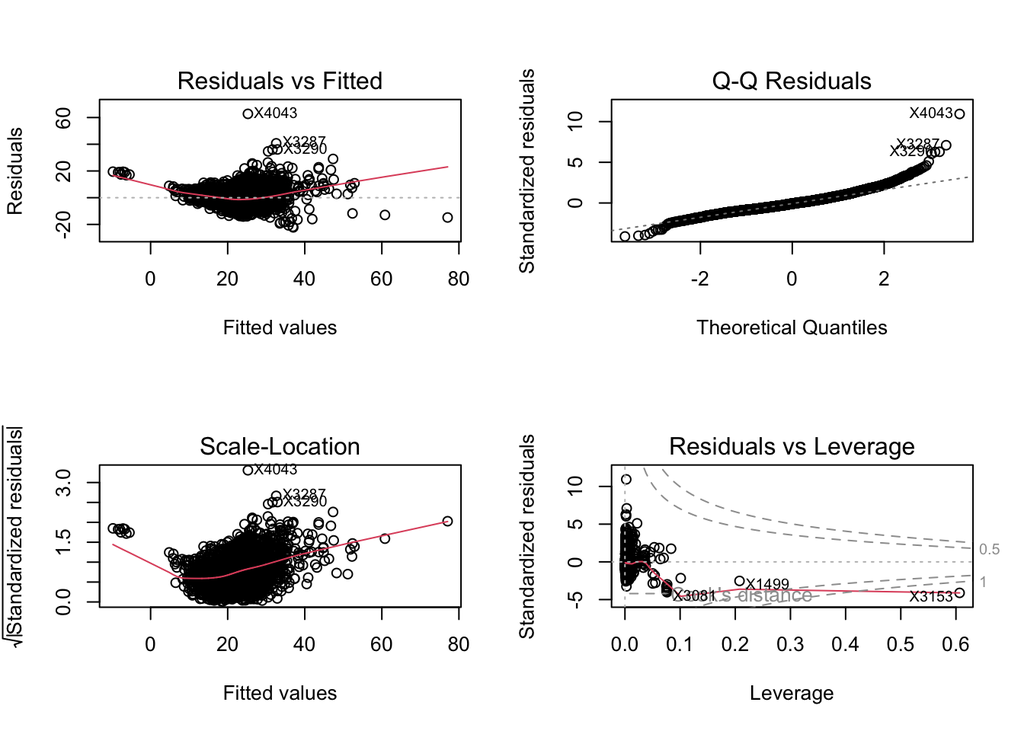

```r
par(mfrow = c(2, 2))
plot(modelcv$finalModel)
```

As we can see from the model fit:

*Residuals vs fitted :* The residuals are fairly randomly scattered, but with a curved, quadratic distribution suggesting our assumption for linearity doesn’t entirely hold.

*Q-Q residuals:* The residuals mostly lie in a diagonal line apart from at the tails, where we see extreme values that are not explained by the model, removing outliers could improve the performance of our model.

*Scale-location:* The residuals are randomly scattered around the line, but with a curvature heavily dropping around 15 on the fitted values, the constant variance assumption doesn’t fully hold.

*Residuals vs leverage:* We see most of our data is clustered around the left hand side of the graph, suggesting we have a left skew. There appear to be a few points of high leverage.

Hence, we haven’t fitted the optimal model since our assumptions have been violated.

Now using our model we can use our true pm10 data for 2021 and test:

```r
test_data_2021$predicted_pm10 <- predict(modelcv, newdata = test_data_2021)
results_2021 <- data.frame(
  city = test_data_2021$city,
  country = test_data_2021$country_name,
  actual_pm10 = test_data_2021$pm10_concentration,
  predicted_pm10 = test_data_2021$predicted_pm10)
```

## Model visualisation

We visualise the relationship between actual pm10 values and predicted pm10 values for European cities in 2021, we have coloured the cities by their corresponding countries:

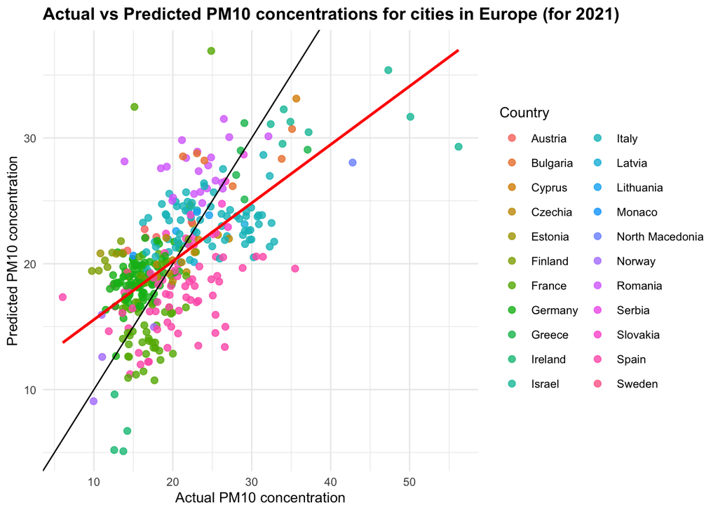

```r
library(ggplot2)
ggplot(results_2021, aes(
  x = actual_pm10,y = predicted_pm10,color = country)) +
  geom_point(alpha = 0.8, size = 2) +
  geom_abline(intercept = 0, slope = 1, color = "black") +geom_smooth(method = "lm", se = FALSE, color = "red")+
  labs(title = "Actual vs Predicted PM10 concentrations for cities in Europe (for 2021)",
    x = "Actual PM10 concentration",y = "Predicted PM10 concentration",
    color = "Country"
  ) +
  theme_minimal(base_size = 10) +
  theme(legend.position = "right",plot.title = element_text(face = "bold"))
```

In our figure we have included the 1:1 reference line (perfect prediction line) in black, and our regression line in red.

We can see from our figure that most of our data is clustered around the lower left of our data set, suggesting many of our pm10 pollution levels are lower in value. There are many points evenly distributed around the 1:1 reference line, suggesting a fairly good model fit, with the exception of a few outliers in cities located in France, Israel, Ireland and Italy. These may be due to political or meteorological conditions that we haven’t considered in our model. We could consider removing these city outlier points, as it would increase the model performance, however this would also introduce a bias to our model. We also note these outlier points are for higher pollution levels, so removing these would lead to a bias towards lower pm10 concentrations.

Overall our model appears to provide a reasonably good prediction for a variety of cities in Europe, however with outliers this has slightly skewed the prediction accuracy of our model for higher level pm10 concentrations.

## Extending our linear regression by regularising

To improve our model, we build upon the ideas of linear regression by regularising, this penalises large coefficients, providing adjustments for multicollinearity. It works by adding the second term in our linear regression:

$$\min_{\boldsymbol{\beta}} \sum_{i=1}^{n} (y_i - \mathbf{x}_i^\top
\boldsymbol{\beta})^2
+ \lambda \left[(1-\alpha)\sum_{j}\beta_j^2 +
\alpha\sum_{j}|\beta_j|\right]$$

There are a variety of ways of doing this, we focus on the following methods:

- Ridge: Reduces the size of all of the coefficients, but keeps them in the model. We have correlation between some predictors so this method should smooth out any instabilities this causes. ($\alpha=0$)
- Lasso: This method is similar to Ridge, but can shrink some coefficients all the way to zero, automatically removing less important variables. $\alpha=1$
- Elastic (combines Ridge and Lasso): It keeps Ridge’s stability and LASSO’s ability to select variables, balancing the two through a mixing parameter $\alpha$

### Ridge

```r
set.seed(2)
#first we try ridge regression
ridge_model <- train(lm_formula_pm10,data = train_data,method = "glmnet",
  trControl = trainControl(method = "cv", number = 5),
  tuneGrid = expand.grid(alpha = 0,lambda = seq(0.0001, 1, length = 50))
)
ridge_model$bestTune
```

```
##    alpha    lambda
## 16     0 0.3061918
```

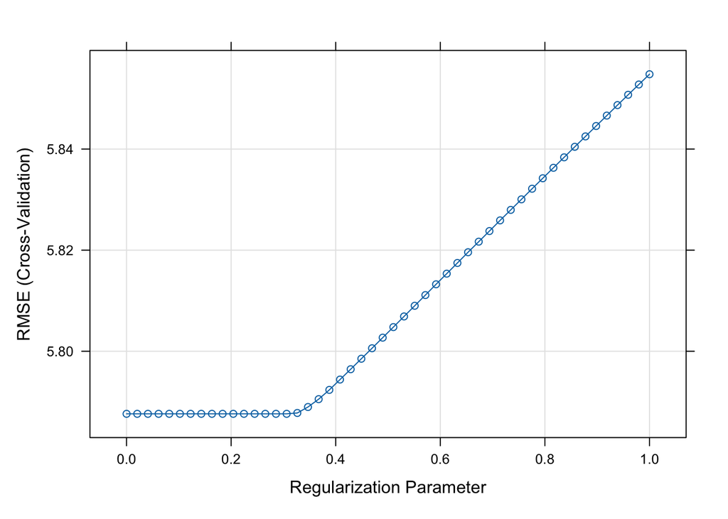

```r
plot(ridge_model)
```

```r
#so now predicting for 2021:
test_data_2021$predicted_pm10_ridge <- predict(ridge_model, newdata = test_data_2021)
```

We can see from our plot that the optimal regularisation parameter is 0.3061918, as beyond this point the RMSE CV increases with lambda (reg parameter), before that it behaves in the same way as our linear regression.

### LASSO

```r
set.seed(2)

lasso_model <- train(lm_formula_pm10,data = train_data,
  method = "glmnet",trControl = trainControl(method = "cv", number = 5),
  tuneGrid = expand.grid(alpha = 1,lambda = seq(0.0001, 1, length = 50))
)
lasso_model$bestTune
```

```
##   alpha     lambda
## 3     1 0.04091224
```

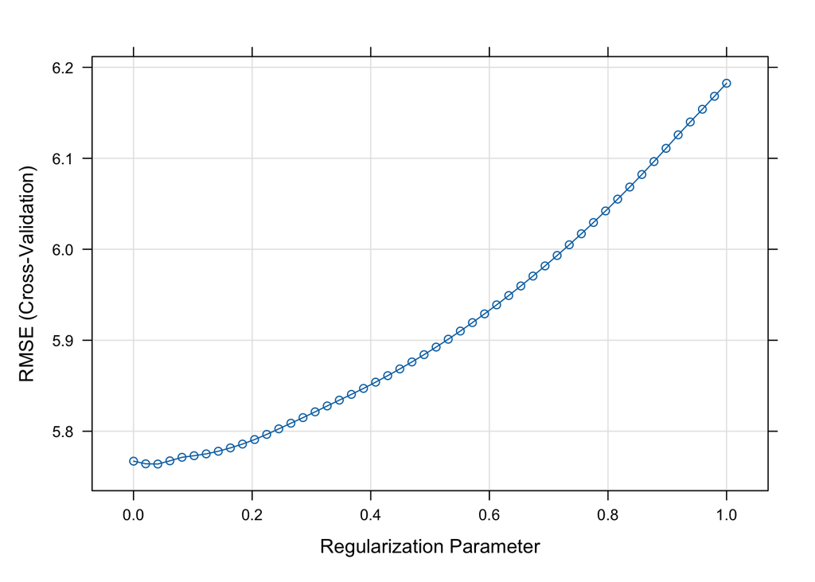

```r
plot(lasso_model)
```

```r
test_data_2021$predicted_pm10_lasso <- predict(lasso_model, newdata = test_data_2021)
```

Similar to Ridge, we can see that the RMSE increases as the regularisation paramter increases, with our best results being around lambda=0.04091224, but again this doesn’t provide very much difference from our original liner regression model.

### Elastic

```r
set.seed(2)

elastic_model <- train(lm_formula_pm10,data = train_data,
method = "glmnet",trControl = trainControl(method = "cv", number = 5),
  tuneGrid = expand.grid(alpha = seq(0, 1, length = 10),lambda = seq(0.0001, 1, length = 50)))

elastic_model$bestTune
```

```
##         alpha     lambda
## 403 0.8888889 0.04091224
```

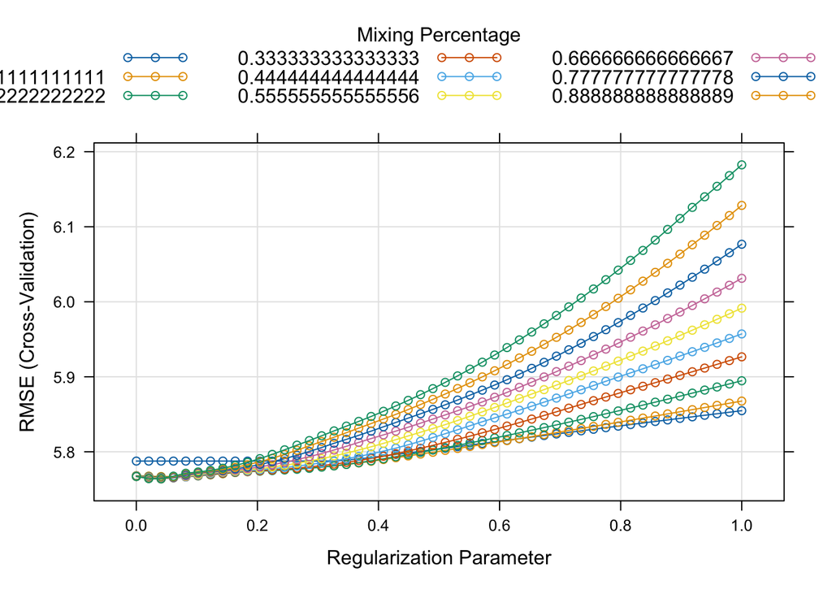

```r
plot(elastic_model)
```

```r
test_data_2021$predicted_pm10_elastic <- predict(elastic_model, newdata = test_data_2021)
```

By combining via elastic net, we see we use approx 88.89% lasso, and approximately 11.11% Ridge, providing a regularisation parameter of lambda= 0.04091224.

### Comparison

```r
comparison <- rbind(
  Linear = postResample(results_2021$predicted_pm10, results_2021$actual_pm10),
  Ridge = postResample(test_data_2021$predicted_pm10_ridge, test_data_2021$pm10_concentration),
  LASSO = postResample(test_data_2021$predicted_pm10_lasso, test_data_2021$pm10_concentration),
  Elastic=postResample(test_data_2021$predicted_pm10_elastic, test_data_2021$pm10_concentration)
)
comparison
```

```
##             RMSE  Rsquared      MAE
## Linear  5.052535 0.3925492 3.915139
## Ridge   5.042155 0.3885257 3.883833
## LASSO   5.056076 0.3915710 3.927623
## Elastic 5.054563 0.3917262 3.924817
```

Evidently, the values we can see in our table are all are fairly similar, so evaluating the performance of each model is more nuanced than a clearly defined optimal model.

We see that the Ridge method has the lowest RMSE (Root Mean Squared Error) of 5.042155, meaning it produces the smallest average prediction error on the unseen 2021 data, making it potentially more accurate.

Regarding the R^2 value, we can see the Linear model has the highest value, suggesting that when we tested our model on our 2021 data, it explained 39.255% of the variation in pm10 concentrations across the european cities.However, compared to Ridge the difference is very small.

Meanwhile the method with the smallest MAE (Mean Absolute Error) is the Ridge method once again. Meaning we can deduce that overall this method deviates the least from our true pm10 concentrations.

Hence we can conclude that the Ridge regularisation linear regression is the best model for our regression, although the differences are very small, it strikes the best balance between bias and variance whuch provides slightly better predictive accuracy.

## Conclusions

We also used transforms of variables, such as log population and polynomial terms for both the no2 concentration and year variables. This helped to capture the non-linearity aspects of our model.

Significant predictors we found were year (which is to be expected given the negative correlation of our pm10 concentrations over time), no2 concentrations spatial locations and log population.

To amend this and further our analysis, we would need to consider additional explanatory variables, these could include:

1. Weather conditions - temperature, wind speed, humidity.
2. Industrial emissions.
3. Traffic density.

Including these variables could help to address the assumption violations we found in our model, potentially increasing the explanatory power of the model and providing us with a better understanding of the factors influencing the pm10 concentration levels for cities in Europe.